# The Costs of Natural Desasters: Tornados Claim the Most Victims, Floods Cause the Highest Damage

## Synopsis

Extreme weather events (natural desasters) can result in fatalities, injuries, and property damage. To enable legislators and administration to determine what action to take to prevent such outcomes to the extent possible, we analysed event outcome data to identify the most critical types of event. We obtained the outcome data from the U.S. National Oceanic and Atmospheric Administration’s (NOAA) storm database. This database tracks characteristics of major storms and weather events in the United States, including when and where they occur, as well as estimates of any fatalities, injuries, and property damage. Our analysis shows that - across the United States - **Tornados claim the most victims** (fatalities and injuries), but **Floods cause the highest damage** (property damage and crop damage).

## Data Processing

We obtained the data from the [NOAA’s National Climatic Data Center Storm Events Database][http://www.ncdc.noaa.gov/stormevents/]. At the time of the download, the database contained data from **January 1950** to **November 2011**.

### Environment

The analysis was performed using *R version 3.2.2 (2015-08-14)* on Microsoft Windows 7 Professional SP1 64-bit (R platform descriptor: *x86_64-w64-mingw32/x64 (64-bit)*).

Additional packages:

| Package | Version |
| --- | --- |
| ggplot2 | 1.0.1 |
| grid | 3.2.2 |
| gridExtra | 2.0.0 |
| stringi | 0.5.5 |

```r
suppressPackageStartupMessages(require(ggplot2))
suppressPackageStartupMessages(require(grid))
suppressPackageStartupMessages(require(gridExtra))
suppressPackageStartupMessages(require(stringi))
```

### Loading the Data

We read the data directly from the compressed archive (bz2 compression). The data is a comma-separated file with column names in row 1. Missing values are given as NULL values, i.e. there is no special coding of missing values.

```r
stormData <- read.csv("./data/repdata_data_StormData.csv.bz2",
                      stringsAsFactors = FALSE)
```

There are 902297 rows in the data set and 37 columns.

```r
dim(stormData)
```

```
## [1] 902297     37
```

```r
colnames(stormData)
```

```
##  [1] "STATE__"    "BGN_DATE"   "BGN_TIME"   "TIME_ZONE"  "COUNTY"
##  [6] "COUNTYNAME" "STATE"      "EVTYPE"     "BGN_RANGE"  "BGN_AZI"
## [11] "BGN_LOCATI" "END_DATE"   "END_TIME"   "COUNTY_END" "COUNTYENDN"
## [16] "END_RANGE"  "END_AZI"    "END_LOCATI" "LENGTH"     "WIDTH"
## [21] "F"          "MAG"        "FATALITIES" "INJURIES"   "PROPDMG"
## [26] "PROPDMGEXP" "CROPDMG"    "CROPDMGEXP" "WFO"        "STATEOFFIC"
## [31] "ZONENAMES"  "LATITUDE"   "LONGITUDE"  "LATITUDE_E" "LONGITUDE_"
## [36] "REMARKS"    "REFNUM"
```

### Checking the data

For our analysis we will use columns *REFNUM*, *EVTYPE*, *FATALITIES*, *INJURIES*, *PROPDMG*, *PROPDMGEXP*, *CROPDMG*, and *CROPDMGEXP* and we checked the first few rows for these columns.

```r
analysisColumns <- c("REFNUM", "EVTYPE", "FATALITIES", "INJURIES",
                     "PROPDMG", "PROPDMGEXP", "CROPDMG", "CROPDMGEXP")
head(stormData[,analysisColumns])
```

```
##   REFNUM  EVTYPE FATALITIES INJURIES PROPDMG PROPDMGEXP CROPDMG CROPDMGEXP
## 1      1 TORNADO          0       15    25.0          K       0
## 2      2 TORNADO          0        0     2.5          K       0
## 3      3 TORNADO          0        2    25.0          K       0
## 4      4 TORNADO          0        2     2.5          K       0
## 5      5 TORNADO          0        2     2.5          K       0
## 6      6 TORNADO          0        6     2.5          K       0
```

Creating a summary for the columns to be used in the analysis shows us that the numerical columns *FATALITIES*, *INJURIES*, *PROPDMG*, and *CROPDMG* don’T contain missing values and are probably ok. (Column *REFNUM* was omitted from the summary as it is just an ID column.)

```r
summary(stormData[,analysisColumns[2:8]])
```

```
##     EVTYPE            FATALITIES          INJURIES
##  Length:902297      Min.   :  0.0000   Min.   :   0.0000
##  Class :character   1st Qu.:  0.0000   1st Qu.:   0.0000
##  Mode  :character   Median :  0.0000   Median :   0.0000
##                     Mean   :  0.0168   Mean   :   0.1557
##                     3rd Qu.:  0.0000   3rd Qu.:   0.0000
##                     Max.   :583.0000   Max.   :1700.0000
##     PROPDMG         PROPDMGEXP           CROPDMG         CROPDMGEXP
##  Min.   :   0.00   Length:902297      Min.   :  0.000   Length:902297
##  1st Qu.:   0.00   Class :character   1st Qu.:  0.000   Class :character
##  Median :   0.00   Mode  :character   Median :  0.000   Mode  :character
##  Mean   :  12.06                      Mean   :  1.527
##  3rd Qu.:   0.50                      3rd Qu.:  0.000
##  Max.   :5000.00                      Max.   :990.000
```

Documentation for the database lists 48 supported entries for column *EVTYPE* and 3 supported entries for columns *PROPDMGEXP* and *CROPDMGEXP*.

A short check however reveals that there are 890 different entries for *EVTYPE* (after trimming leading and trailing spaces and transforming to upper case).

```r
evtypes <- unique(stri_trans_toupper(stri_trim(stormData$EVTYPE)))
evtypes <- evtypes[order(evtypes)]
summary(evtypes)
```

```
##    Length     Class      Mode
##       890 character character
```

Similar for *PROPDMGEXP* and *CROPDMGEXP*. Instead of the three supported entries there are 17 different values.

```r
exptypes <- unique(c(stri_trans_toupper(stri_trim(stormData$PROPDMGEXP)),
                     stri_trans_toupper(stri_trim(stormData$CROPDMGEXP))))
exptypes <- exptypes[order(exptypes)]
summary(exptypes)
```

```
##    Length     Class      Mode
##        17 character character
```

## Results

### Impact on Population Health

To measure the impact on population help we decided to use the total number of victims (sum of fatalities and injuries).

```r
## Get subset of data
victims <- stormData[, c("REFNUM", "EVTYPE", "FATALITIES", "INJURIES")]
victims <- subset(victims, victims$FATALITIES > 0 | victims$INJURIES > 0)
victims$EVTYPE <- stri_trans_toupper(stri_trim(victims$EVTYPE))

## Calculate total number of victims and aggregate by event type
victims$VICTIMS <- victims$FATALITIES + victims$INJURIES
victims_byType <- aggregate(victims[c("FATALITIES", "INJURIES", "VICTIMS")],
                            by = victims["EVTYPE"], FUN = sum)
```

Sorting by the number of victims from high to low shows that **tornados claim by far the highest number of victims**.

```r
victims_byType_all <- victims_byType[order(victims_byType$VICTIMS,
                                           decreasing = TRUE),]
head(victims_byType_all)
```

```
##             EVTYPE FATALITIES INJURIES VICTIMS
## 169        TORNADO       5633    91346   96979
## 27  EXCESSIVE HEAT       1903     6525    8428
## 176      TSTM WIND        504     6957    7461
## 41           FLOOD        470     6789    7259
## 111      LIGHTNING        816     5230    6046
## 61            HEAT        937     2100    3037
```

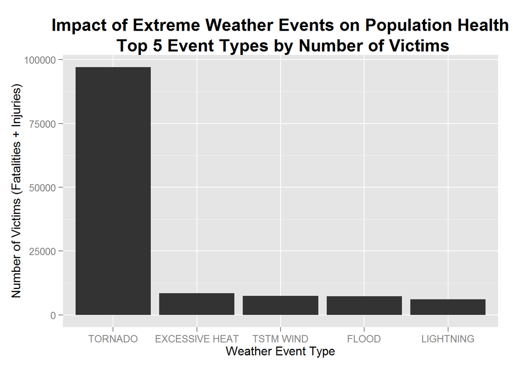

```r
ggplot(victims_byType_all[1:5,], aes(y = VICTIMS, x = EVTYPE)) +
    geom_bar(stat = "identity") +
    scale_x_discrete(limits = victims_byType_all$EVTYPE[1:5]) +
    ggtitle("Impact of Extreme Weather Events on Population Health\n Top 5 Event Types by Number of Victims") +
    theme(plot.title=element_text(size=rel(1.4), lineheight=1.0,
                                  face="bold")) +
    xlab("Weather Event Type") + ylab("Number of Victims (Fatalities + Injuries)")
```

### Economic Consequences

In the database there are separate entries for property damage and crop damage. To measure economic consequences we decided to use the sum of property and crop damage.

Damages are not given by a single number but in a kind of scientific notation with the mantissa in fields *xROPDMG* and the exponent in fields *xROPDMGEXP*. Addionally the exponent is coded as K (10<sup>3</sup>), M (10<sup>6</sup>), and B (10<sup>9</sup>). To get the value of the damages it is therefore necessary to first decode the exponent and then multiply mantissa and exponent.

```r
## Get subset of data
damage <- stormData[, c("REFNUM", "EVTYPE", "PROPDMG", "PROPDMGEXP", "CROPDMG", "CROPDMGEXP")]
damage <- subset(damage, damage$PROPDMG > 0 | damage$CROPDMG > 0)
damage$EVTYPE <- stri_trans_toupper(stri_trim(damage$EVTYPE))
damage$PROPDMGEXP <- stri_trans_toupper(damage$PROPDMGEXP)
damage$CROPDMGEXP <- stri_trans_toupper(damage$CROPDMGEXP)

## Decode exponents
getEXP_strict <- function(x) {
    if (x == "") {
        1
    }
    else {
        switch(x,
               K = 1000,
               M = 1000000,
               B = 1000000000,
               NA)
    }
}

damage$PROPEXP_strict <- sapply(damage$PROPDMGEXP, FUN = getEXP_strict, USE.NAMES = FALSE)
damage$CROPEXP_strict <- sapply(damage$CROPDMGEXP, FUN = getEXP_strict, USE.NAMES = FALSE)

## Calculate total damage and  aggregate by event type
damage$PROPDMG_strict <- mapply(function(x, y) {x * y},
                                damage$PROPDMG, damage$PROPEXP_strict, USE.NAMES = FALSE)
damage$CROPDMG_strict <- mapply(function(x, y) {x * y},
                                damage$CROPDMG, damage$CROPEXP_strict, USE.NAMES = FALSE)
damage$DMG_strict <- damage$PROPDMG_strict + damage$CROPDMG_strict
damage_byType <- aggregate(damage["DMG_strict"],
                           by = damage["EVTYPE"], FUN = sum)
```

Sorting by the value of damages from high to low shows that **floods cause the highest damages**.

```r
damage_byType_strict <- damage_byType[order(damage_byType$DMG_strict, decreasing = TRUE),]
head(damage_byType_strict)
```

```
##                EVTYPE   DMG_strict
## 62              FLOOD 150319678257
## 177 HURRICANE/TYPHOON  71913712800
## 270       STORM SURGE  43323541000
## 31            DROUGHT  15018672000
## 169         HURRICANE  14610229010
## 236       RIVER FLOOD  10148404500
```

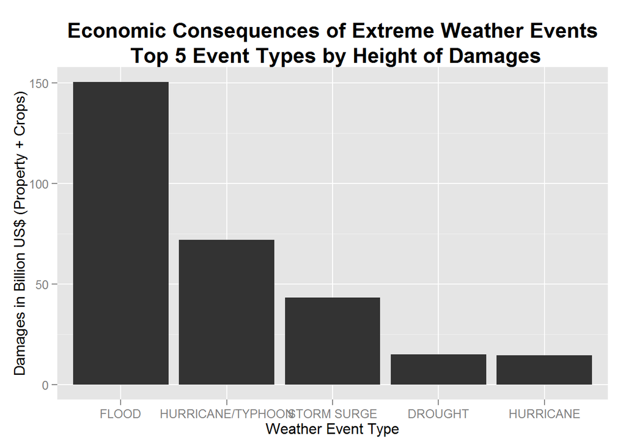

```r
ggplot(damage_byType_strict[1:5,], aes(y = DMG_strict/1000000000, x = EVTYPE)) +
    geom_bar(stat = "identity") +
    scale_x_discrete(limits = damage_byType_strict$EVTYPE[1:5]) +
    ggtitle("Economic Consequences of Extreme Weather Events\n Top 5 Event Types by Height of Damages") +
    theme(plot.title=element_text(size=rel(1.4), lineheight=1.0,
                                  face="bold")) +
    xlab("Weather Event Type") + ylab("Damages in Billion US$ (Property + Crops)")
```